# Validation & Cleaning of NYPD Arrests Data Set

Darshan Patel

11/22/2019

Load in libraries.

```r
# Load libraries for reading and manipulating data
library(tidyverse)
library(lubridate)
library(sf)
library(proj4)
```

Link for data set: https://data.cityofnewyork.us/Public-Safety/NYPD-Arrests-Data-Historic-/8h9b-rp9u.

```r
# Read in data
arrests = read_delim('NYPD_Arrests_Data__Historic_.csv', delim = ',')
```

Investigate the size of the data.

```r
# Get size of the data set
dim(arrests)
```

```
## [1] 4798339      18
```

There are 4798339 arrests made in NYC in the time frame of this data set. There are 18 variables for each record. This is consistent with the information shared on the website.

To validate the data, look at each column and check if the data is valid and consistent. **NOTE**: Use the footnote of the data set to determine if discrepancies should be ignored.

```r
# Get list of columns
colnames(arrests)
```

```
##  [1] "ARREST_KEY"        "ARREST_DATE"       "PD_CD"
##  [4] "PD_DESC"           "KY_CD"             "OFNS_DESC"
##  [7] "LAW_CODE"          "LAW_CAT_CD"        "ARREST_BORO"
## [10] "ARREST_PRECINCT"   "JURISDICTION_CODE" "AGE_GROUP"
## [13] "PERP_SEX"          "PERP_RACE"         "X_COORD_CD"
## [16] "Y_COORD_CD"        "Latitude"          "Longitude"
```

There are 18 columns to validate.

The `ARREST_KEY` column is used to give a randomly generated ID for each arrest. Check if all arrests are unique and there is no repeated arrest record.

```r
# Get vector of unique keys and check its length with actual column
length(unique(arrests$ARREST_KEY)) == length(arrests$ARREST_KEY)
```

```
## [1] TRUE
```

All IDs are unique.

The `ARREST_DATE` column is used to record the exact date of arrest for the reported event. Determine the time frame of the column.

```r
# Convert the column to Date type for easy use
arrests$ARREST_DATE = as.Date(arrests$ARREST_DATE, "%m/%d/%Y")
```

The earliest and latest record shown, respectively, is

```r
min(arrests$ARREST_DATE)
```

```
## [1] "2006-01-01"
```

```r
max(arrests$ARREST_DATE)
```

```
## [1] "2018-12-31"
```

For the purpose of this analysis, the data will be subsetted such that records from 2015 onwards will be shown.

```r
# Remove records of pre-2015 data
arrests = arrests %>% subset(year(ARREST_DATE) >= 2015)
```

Check that the earliest record was in 2015.

```r
# Get earliest date
min(arrests$ARREST_DATE)
```

```
## [1] "2015-01-01"
```

Column is cleaned.

The `PD_CD` column is a 3 digit internal classification code. Check for records with no classification code.

```r
# Get number of records with no classification code
sum(is.na(arrests$PD_CD))
```

```
## [1] 69
```

There are 69 records with no classification code. According to the footnote documentation, null values may appear frequently due to changes on official department forms or if information was not available or unknown at the time.

Check if the records with no internal classification code are random or have a pattern of occurrence.

```r
# Get index of which arrests have no code
which(is.na(arrests$PD_CD))
```

```
##  [1] 942006 943157 945965 952348 953300 954705 960234 965248 968309 969469
## [11] 972859 974520 985359 987485 987912 988212 988216 988389 988874 989163
## [21] 989289 989374 989468 989527 989624 989887 989965 990075 990130 990431
## [31] 990490 991604 991746 991959 992181 992182 992484 992564 992842 993305
## [41] 993414 993580 993597 993648 993799 993800 994066 994180 994187 994189
## [51] 994237 994284 994316 994388 994417 994438 994687 994846 995039 995785
## [61] 995823 995878 996108 996293 996612 997478 997484 997580 997620
```

```r
# Look at few of the records with no code
head(arrests[(is.na(arrests$PD_CD)),], 10)
```

| ARREST_KEY | ARREST_DATE | PD_CD | PD_DESC | KY_CD | OFNS_DESC | LAW_CODE | LAW_CAT_CD | ARREST_BORO | ARREST_PRECINCT | JURISDICTION_CODE | AGE_GROUP | PERP_SEX | PERP_RACE | X_COORD_CD | Y_COORD_CD | Latitude | Longitude |
| --- | --- | --- | --- | --- | --- | --- | --- | --- | --- | --- | --- | --- | --- | --- | --- | --- | --- |
| 191627084 | 2018-12-28 | NA | NA | NA | NA | NA | NA | B | 44 | 0 | 18-24 | M | BLACK | 1007972 | 244067 | 40.83656 | -73.91427 |
| 191539440 | 2018-12-26 | NA | NA | NA | NA | PL 2203400 | F | M | 5 | 0 | 45-64 | M | BLACK | 986219 | 201582 | 40.71998 | -73.99290 |
| 191351419 | 2018-12-20 | NA | NA | NA | NA | NA | NA | K | 73 | 0 | 45-64 | M | BLACK | 1008831 | 187388 | 40.68099 | -73.91138 |
| 190932018 | 2018-12-09 | NA | NA | NA | NA | NA | NA | Q | 115 | 0 | 18-24 | M | WHITE HISPANIC | 1022862 | 212950 | 40.75110 | -73.86064 |
| 190919163 | 2018-12-08 | NA | NA | NA | NA | NA | NA | B | 48 | 0 | 25-44 | M | BLACK | 1015844 | 246036 | 40.84194 | -73.88582 |
| 190812587 | 2018-12-06 | NA | NA | NA | NA | NA | NA | M | 13 | 0 | 25-44 | M | WHITE | 989360 | 206199 | 40.73265 | -73.98156 |
| 190467679 | 2018-11-27 | NA | NA | NA | NA | NA | NA | K | 73 | 0 | 25-44 | M | BLACK | 1009519 | 180676 | 40.66256 | -73.90892 |
| 190138810 | 2018-11-18 | NA | NA | NA | NA | NA | NA | K | 75 | 97 | 25-44 | M | WHITE HISPANIC | 1017228 | 183349 | 40.66987 | -73.88112 |
| 189903730 | 2018-11-13 | NA | NA | NA | NA | NA | NA | B | 40 | 0 | 25-44 | F | BLACK | 1010580 | 236353 | 40.81538 | -73.90488 |
| 189850062 | 2018-11-11 | NA | NA | NA | NA | NA | NA | K | 73 | 97 | 25-44 | M | BLACK | 1010482 | 185602 | 40.67608 | -73.90543 |

Note that with the missing classification code, `PD_DESC`, `KY_CD`, `OFNS_DESC`, and some of the `LAW_CODE` columns were also missing data. All of these fields should be filled with an `UNKNOWN` value.

Impute missing value in `PD_CD` column. Check if done properly.

```r
# Impute missing value
arrests$PD_CD[is.na(arrests$PD_CD)] = "UNKNOWN"
# Check if any missing values appear
any(is.na(arrests$PD_CD))
```

```
## [1] FALSE
```

No missing values.

The `PD_DESC` column gives the description of the internal classification code. The records with missing value can be imputed with `UNKNOWN` since its description of the arrest cannot be inferred.

```r
# Impute missing value
arrests$PD_DESC[is.na(arrests$PD_DESC)] = "UNKNOWN"
# Check if any missing values left
any(is.na(arrests$PD_DESC))
```

```
## [1] FALSE
```

No missing values.

The `KY_CD` column gives a 3 digit internal classification code which is more general than the PD code. Impute the missing values and check if done properly.

```r
# Impute missing value
arrests$KY_CD[is.na(arrests$KY_CD)] = "UNKNOWN"
# Check if any missing values left
any(is.na(arrests$KY_CD))
```

```
## [1] FALSE
```

The `OFNS_DESC` column describes the classification associated with the KY code. Impute the missing values and check if done properly.

```r
# Impute missing values
arrests$OFNS_DESC[is.na(arrests$OFNS_DESC)] = "UNKNOWN"
# Check if any missing values left
any(is.na(arrests$OFNS_DESC))
```

```
## [1] FALSE
```

The `LAW_CODE` column gives the law code charges corresponding to the NYS Penal Law, VTL and other various local laws. It was previously noted that, unlike the previous code columns, not all of the law codes are missing when the classification code itself is missing. Any determination of the actual code cannot be done since it can come from various sources. Impute the missing values and check if done properly.

```r
# Impute missing values
arrests$LAW_CODE[is.na(arrests$LAW_CODE)] = "UNKNOWN"
# Check if any missing values left
any(is.na(arrests$LAW_CODE))
```

```
## [1] FALSE
```

The `LAW_CAT_CD` column tells the level of offense: felony, misdemeanor, violation.

```r
# Look at the summary of the column
summary(as.factor(arrests$LAW_CAT_CD))
```

```
##      F      I      M      V   NA's
## 361634   5168 770270  44163   6097
```

There appears to be a new value, “I”, which is not discussed in the footnote of the data set. Investigate those crimes.

```r
# Get few observations that have an "I" for level of offense
# and some information on it
head(arrests[arrests$LAW_CAT_CD == 'I', c('PD_DESC', 'LAW_CODE', 'LAW_CAT_CD')], 10)
```

| PD_DESC | LAW_CODE | LAW_CAT_CD |
| --- | --- | --- |
| TRAFFIC,UNCLASSIFIED INFRACTION | VTL0375BIB | I |
| NA | NA | NA |
| UNLICENSED OPERATOR | VTL0509001 | I |
| NA | NA | NA |
| NA | NA | NA |
| LIGHTS,IMPROPER | VTL03750XA | I |
| LIGHTS,IMPROPER | VTL03750XA | I |
| UNLICENSED OPERATOR | VTL0509001 | I |
| TRAFFIC,UNCLASSIFIED INFRACTION | VTL0375030 | I |
| TRAFFIC,UNCLASSIFIED INFRACTION | VTL037502A | I |

Given by the information in the above table, and research from the internet, the “I” refers to traffic infractions, defined by the VTL. These are minor traffic violations such as exceeding the speed limit, running stop signs, etc. In terms of severity, it is the least severe of all four offenses.

Look at the description of arrests for which level of offenses is not given.

```r
# See what unknown law code records say about its description
table(arrests[is.na(arrests$LAW_CAT_CD), 'PD_DESC'])
```

```
##
##                   F.C.A. ORDER OF PROTECTION
##                                            1
##                           F.O.A. NON-SUPPORT
##                                            3
## FUGITIVE,FROM OTHER JURISDICTION IN NY STATE
##                                          106
##                   FUGITIVE,FROM OTHER STATES
##                                         1524
##                 NY CITY,UNCLASSIFIED WARRANT
##                                           14
##                              NY STATE,PAROLE
##                                           37
##                           NY STATE,PROBATION
##                                            2
##                        NY STATE,UNCLASSIFIED
##                                           42
##                                      UNKNOWN
##                                           45
##                         US CODE,UNCLASSIFIED
##                                         4323
```

Information on the arrest itself is either unclassified, from other states or on parole. For this analysis, an `UNKNOWN` will be placed for the null values.

```r
# Impute missing values
arrests$LAW_CAT_CD[is.na(arrests$LAW_CAT_CD)] = "UNKNOWN"
# Check if any missing values left
any(is.na(arrests$LAW_CAT_CD))
```

```
## [1] FALSE
```

The `ARREST_BORO` column tells which of the 5 boroughs the arrest was made in. There should be no issues here. Check if only boroughs are named.

```r
# Get table of values for boroughs
table(as.factor(arrests$ARREST_BORO))
```

```
##
##      B      K      M      Q      S
## 262939 329285 318105 231739  45264
```

Only the 5 NYC boroughs are mentioned here. Check for missing values.

```r
any(is.na(arrests$ARREST_BORO))
```

```
## [1] FALSE
```

No missing values or strange values. The column is cleaned.

The `ARREST_PRECINCT` column tells which precinct the arrest occured in. Check if the values are numeric and there are no null values.

```r
# Check for valid values
table(arrests$ARREST_PRECINCT)
```

```
##
##     1     5     6     7     9    10    13    14    17    18    19    20
## 13772 20580 12566 11200 12511 10347 17655 41823  6240 18958 10947  7190
##    22    23    24    25    26    28    30    32    33    34    40    41
##   978 17481  9089 25883  8376 13957 10591 17272 14300 16206 37561 21336
##    42    43    44    45    46    47    48    49    50    52    60    61
## 21235 23495 33709 10777 23221 22056 21464 14577  6991 26514 17525 10352
##    62    63    66    67    68    69    70    71    72    73    75    76
##  9366  8524  6930 22396 10169 10813 16143 15920 13437 28504 36862  8412
##    77    78    79    81    83    84    88    90    94   100   101   102
## 16698  8793 17562 12792 14612 16593  8117 12862  5907  7591 11496 15814
##   103   104   105   106   107   108   109   110   111   112   113   114
## 24541 12158 14830 12462 10962  8563 16769 17301  5501  7308 26099 20568
##   115   120   121   122   123
## 19958 18146 13168  8117  5833
```

```r
any(is.na(arrests$ARREST_PRECINCT))
```

```
## [1] FALSE
```

Alll data is numeric and there are no missing data.

According to the NYPD website, there are 77 unique precincts in NYC. Check if this is true for the data set.

```r
# Get number of unique precincts
length(unique(arrests$ARREST_PRECINCT))
```

```
## [1] 77
```

Furthermore, verify that the 77 unique precincts are exactly the same as the ones defined by the NYPD. For this, use the shapefile published by NYC Planning agency for “Police Precincts” under the School, Police, Health & Fire menu. This shapefile will provide information on all the precincts such as its name and geographical location. (Source: https://www1.nyc.gov/site/planning/data-maps/open-data/districts-download-metadata.page)

```r
# Read in shapefile of the NYC police precincts
sf = read_sf('.', 'nypp')
# Check that all the precincts in the data set are valid
all(sf$Precinct == sort(unique(arrests$ARREST_PRECINCT)))
```

```
## [1] TRUE
```

All precincts are valid NYPD precincts. The data is correct.

*NOTE: By value, the precincts in the data set matches the one used by the NYPD in the shapefile. However, the New York City Council uses a different mapping of NYC precincts, one that has only 51 precincts. For extreme accuracy in analysis, it would be best to map the precincts to the one used by the NYCC since this report will be read by the Council staffer. For this analysis, this cleaning process will be left out as it is not too important.*

The `JURISDICTION_CODE` column tells what jurisdiction was responsible for the arrest. Check for missing values.

```r
# Determine if there are any missing values
sum(is.na(arrests$JURISDICTION_CODE))
```

```
## [1] 0
```

No missing values. Investigate the count of different codes.

```r
# Get table of jurisdiction code
table(arrests$JURISDICTION_CODE)
```

```
##
##      0      1      2      3      4      6      7      8      9     11
## 982779 106459  60860  12215   2160   1963    771      2    157    997
##     12     13     14     15     16     69     71     72     73     74
##    198     79    612    915    101    540    419   5195   1490     29
##     76     79     85     87     88     97
##      2     25    184    226    162   8792
```

A look at the different jurisdiction codes indicate that there are many codes greater than 3, which represent non-NYPD jurisdictions. This is reflected in the footnote documentation.

The `AGE_GROUP` column reveals the age category of the perpetrator. Check for missing values and odd values.

```r
# Get table of age group
table(arrests$AGE_GROUP)
```

```
##
##    <18  18-24  25-44  45-64    65+
##  70564 291164 584071 229536  11997
```

No missing data.

The `PERP_SEX` column reveals the sex of the perpetrator. Check for missing values and odd values.

```r
# Get table of sexes
table(arrests$PERP_SEX)
```

```
##
##      F      M
## 206364 980968
```

No missing data.

The `PERP_RACE` column reveals the race of the perpetrator. Check for missing values and odd values.

```r
# Get table of races
table(arrests$PERP_RACE)
```

```
##
## AMERICAN INDIAN/ALASKAN NATIVE       ASIAN / PACIFIC ISLANDER
##                           2934                          58869
##                          BLACK                 BLACK HISPANIC
##                         567200                         101422
##                        UNKNOWN                          WHITE
##                          10952                         144302
##                 WHITE HISPANIC
##                         301653
```

No missing data.

The `X_COORD_CD` and `Y_COORD_CD` columns give the midblock X and Y coordinate from the NYS Plane Coordinate System, respectively. The `Latitude` and `Longitude` columns give the latitude and longitude coordinates respectively. These values give the location of the arrest made.

First, check that the midblock coordinates given using the NYS Plane Coordinate System correctly project into the latitude and longitude coordinates given.

In order to do this, the projection must be defined. This can be found at: https://spatialreference.org/ref/epsg/2263/, which gives the Proj4js format for the EPSG projection 2263 - NAD83 / New York Long Island (ftus). Note that it was last revised in Nov 2001. A better verification method could be utilized.

```r
# Set up projection attributes
proj4string = "+proj=lcc +lat_1=41.03333333333333 +lat_2=40.66666666666666 +lat_0=40.16666666666666 +lon_0=-74 +x_0=300000.0000000001 +y_0=0 +ellps=GRS80 +datum=NAD83 +to_meter=0.3048006096012192 +no_defs"
# Create data frame to store coordinates
xy = data.frame(x=arrests$X_COORD_CD, y = arrests$Y_COORD_CD)
# Project the coordinates into geographical lat/long coordinates
pj = project(xy, proj4string, inverse = TRUE)
```

Get the differences in the latitude and longitude values recorded in the data set and the projection.

```r
# Find differences in coordinate locations
lat_difference = pj$y - arrests$Latitude
long_difference = pj$x - arrests$Longitude
```

Look at the biggest difference in coordinate calculation and reported latitude/longitude values.

```r
# Print maximum differences
max(lat_difference)
```

```
## [1] -8.205221e-06
```

```r
max(long_difference)
```

```
## [1] 1.516201e-06
```

These values are very tiny; it is safe to safe that the X and Y coordinates from the NYS Plane Coordinate System match the latitude and longitude coordinates given.

Check that the coordinates (from the NYS Plane Coordinate System) belong in NYC. For this, plot the shape file to show boundaries of NYC and its precincts. On the map of NYC, plot the coordinates of the arrests made.

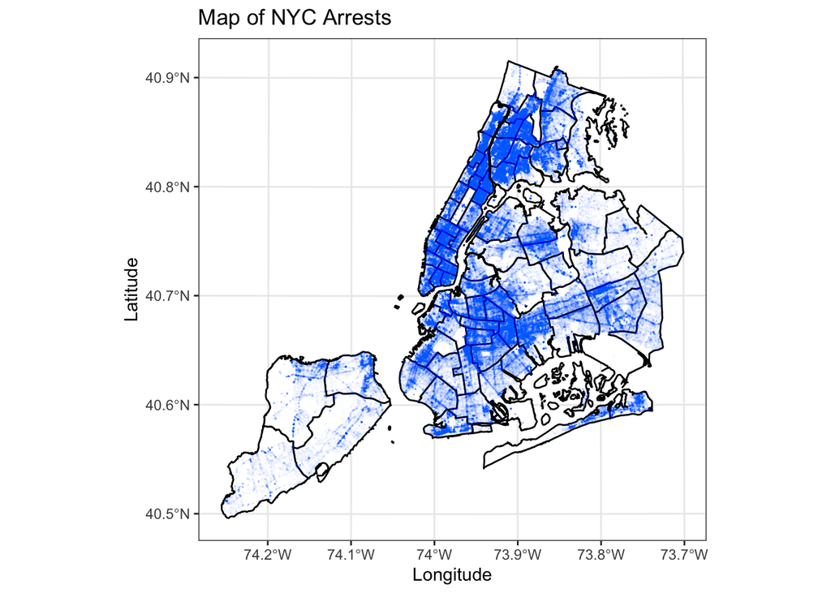

```r
# Plot shapefile and midblock X & Y coordinates of arrests
ggplot(sf) +
  geom_sf(color = "black", fill = "white") +
  geom_point(data = arrests,
             aes(x = X_COORD_CD, y = Y_COORD_CD),
             size = 0.005, alpha = 0.01, color = "dodgerblue1") +
  labs(x = "Longitude", y = "Latitude",
       title = "Map of NYC Arrests") +
  coord_sf(crs = st_crs(2263)) +
  theme_bw()
```

All records of arrests are clearly within the boundary of NYC.

For more accurate verification, check that each arrest was made in the correct precinct using the geometry of the precinct from the shapefile and the coordinates given in the data set. For this analysis, it will be left out.

This data set is now validated and cleaned. Export the cleaned data set.

```r
# Create csv file for cleaned data set
arrests %>% write_csv("arrests_cleaned.csv")
```